# We're Not Getting Our Money's Worth:

## An Analysis of Health Outcomes in Universal, Blended, and Private Health Systems

### By Mia Venezia

# Background

- US healthcare costs are 17.8% of GDP
- Most Americans US believe healthcare is too expensive but good, if you are insured
- Nationalized healthcare and blended systems are less expensive and would cover everyone
- How does increased access affect health outcomes?

# Literary Context

- UK National Health Service (NHS)
- Australian Basic Universal Coverage
- Indonesian National Healthcare Coverage

*There are pros and cons to all systems, and policy makers must balance cost and quality.*

# Mission and Methods

**Mission**

This paper uses several health outcomes as indicators of healthcare access to determine if the cost of care in the US is commensurate with the access it affords as compared to cost and access in countries with national healthcare or a blended system of healthcare coverage.

**Methods**

- Healthcare Expenditures as a Percentage of GDP
- Infant Mortality Rate
- Average Longevity
- Cardiovascular Deaths
- Scatter plot graphs were developed for each variable with groups and the US identified by color.

*A separate analysis of data from Taiwan was performed using a standard t-test to determine if longevity differences before and after national health care were significant.*

# Results

[output not shown]

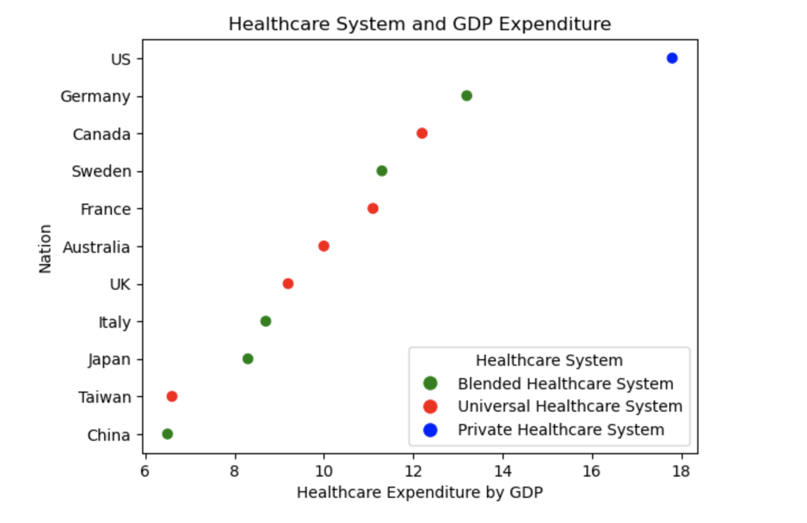

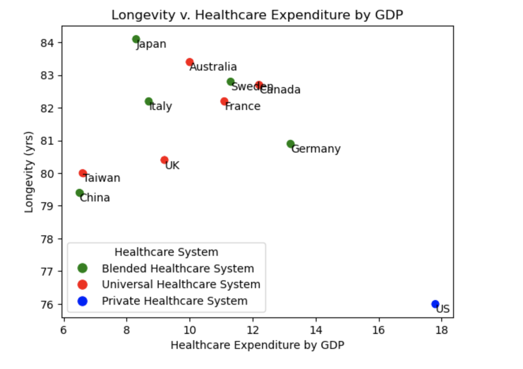

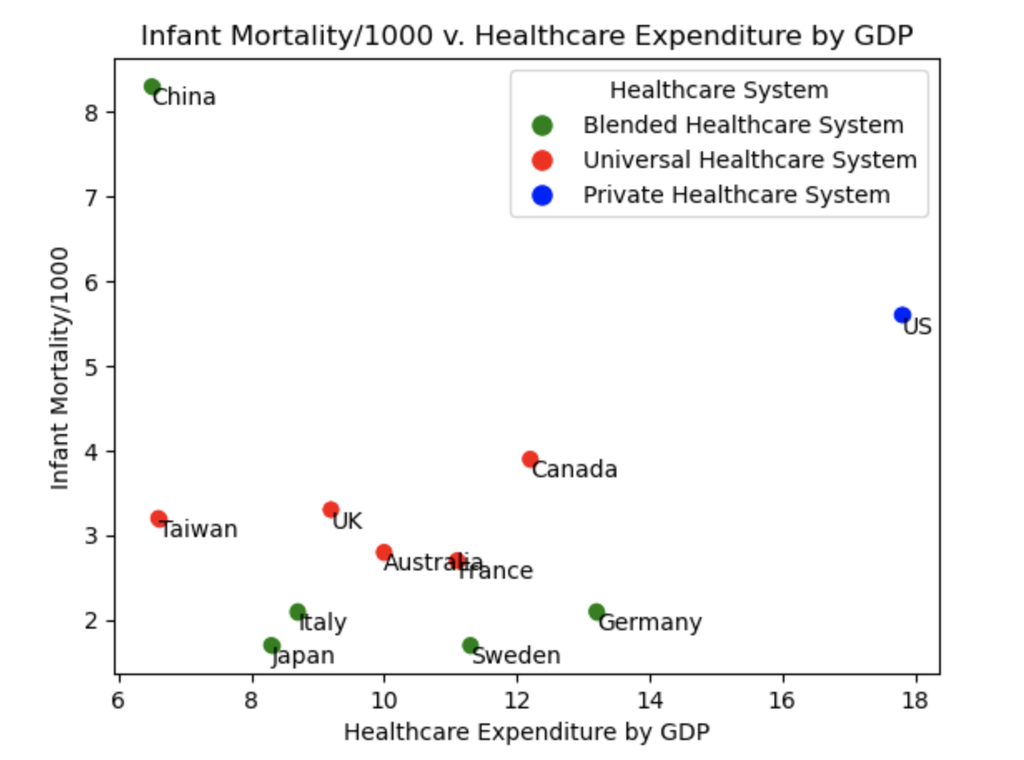

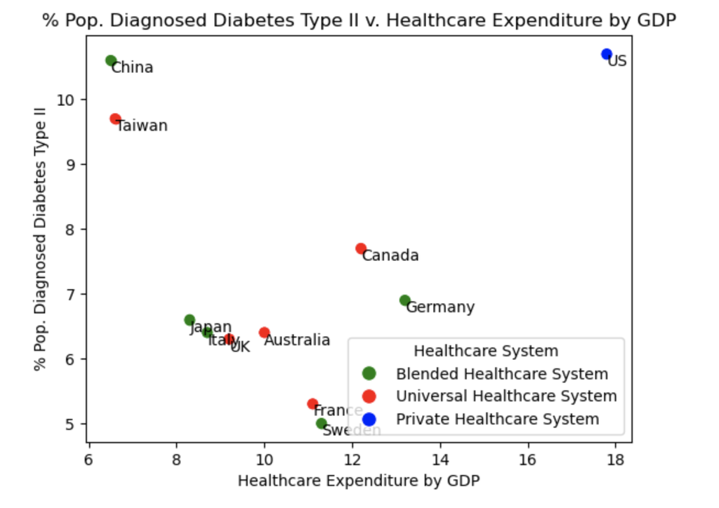

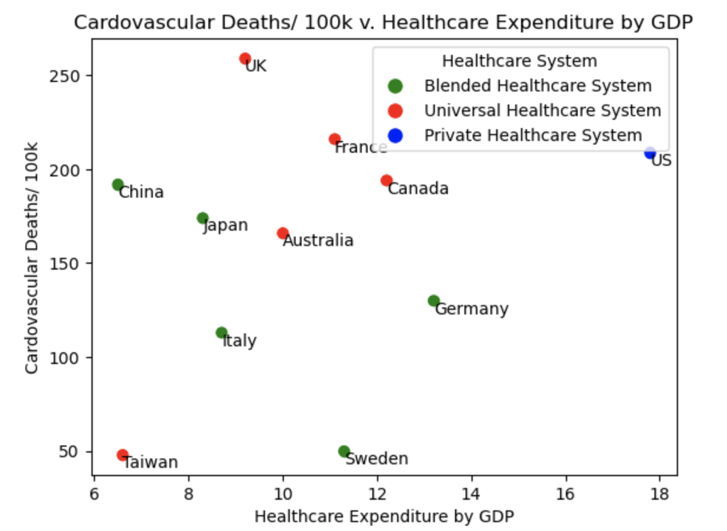

# Discussion

**Before and After: A Case Study**

Taiwan instituted national health care in 1995. Since that time, healthcare expenditures per GDP have remained steady between 5 and 7% GDP

```python
import numpy as np
from scipy import stats

# Set seed for reproducibility (can be any integer)
np.random.seed(123)

# Generate example data
group1 = np.random.normal(loc=2.5000, scale=0.2300, size=2)
group2 = np.random.normal(loc=2.5850, scale=0.2748, size=2)

# Perform t-test for independent samples
t_stat, p_value = stats.ttest_ind(group1, group2)

# Print results
print(f'T-statistic: {t_stat}')
print(f'P-value: {p_value}')

# Check if the difference is statistically significant (common alpha level is 0.05)
alpha = 0.05
if p_value < alpha:
    print("The difference in means is statistically significant.")
else:
    print("There is no significant difference in means.")
```

```
T-statistic: 0.2124713121811935
P-value: 0.8514275285966173
There is no significant difference in means.
```

# Conclusion

- The United States is literally not getting an appropriate bang for its healthcare “buck.”
- The Taiwan experience supports the theory that national coverage may not provide dramatic benefits for those who had private health insurance prior to the institution of national healthcare, but does equalize health care access for those who could not previously afford care.